# Seasalt Coding Round v2

### Library Import

```python
import pandas as pd
import numpy as np
import re

from collections import defaultdict

from numpy import array
from numpy import argmax
from matplotlib import pyplot

from sklearn.preprocessing import LabelEncoder
from sklearn.preprocessing import OneHotEncoder
from sklearn.model_selection import cross_val_score
from sklearn.model_selection import train_test_split
from sklearn.naive_bayes import MultinomialNB
from sklearn.feature_extraction.text import CountVectorizer
import statsmodels.formula.api as smf
from sklearn.metrics import mean_squared_error,accuracy_score
from sklearn.preprocessing import StandardScaler
from sklearn.decomposition import PCA

import tensorflow as tf
from tensorflow.keras.preprocessing.text import Tokenizer
from tensorflow.keras.preprocessing.sequence import pad_sequences

from tensorflow.keras.models import Sequential, Model
from tensorflow.keras.layers import Dense, LSTM, Conv1D, Embedding, Input, TimeDistributed, Activation
from tensorflow.keras.layers import MaxPooling1D, SpatialDropout1D, Dropout, Concatenate, Flatten, RepeatVector, Permute
from tensorflow.keras.callbacks import EarlyStopping
from tensorflow.keras.layers import Multiply, Lambda
from tensorflow.keras.backend import sum as Ksum

from tensorflow.keras.models import load_model, model_from_json
from tensorflow.keras.utils import plot_model
```

### 1. Data Loading

#### 1.1 Utility functions to help with data loading

```python
def read_text(file_path):
    extract=open(file_path,'r',encoding='utf-8')
    extracted=extract.read()
    extract.close()
    return extracted
def clean_line(line):
    clean_line = re.sub(' +',' ',line)
    if clean_line[0] == ' ':
        clean_line = clean_line[1:]
    return clean_line
def strip_ends(text_inp,ends):
    text_op=[]
    for text_line, ends in zip(text_inp,ends):
        text_op.append(text_line[ends[0]+1:ends[1]])
    return text_op
```

#### 1.2 Read text

```python
feneme_set=read_text(r'feneme_set.txt').split('\n')
feneme_set=feneme_set[:-1]
train_features_r=[feneme.split(' ') for feneme in read_text(r'train_features.txt').split('\n')]
train_transcripts_r=[word for word in read_text(r'train_transcripts.txt').split('\n')]
train_endpoints_r=[points for points in read_text(r'train_endpoints.txt').split('\n')]
```

#### 1.3 Parse endpoints

```python
train_endpoints=[]
for line in train_endpoints_r:
        s=clean_line(line).split(' ')
        train_endpoints.append([int(s[0]),int(s[1])])
```

```python
train_features=strip_ends(train_features_r,train_endpoints)
```

### 2 Categorical to Real Space

#### 2.1 One hot encoding for labels

```python
train_transcripts_array = array(train_transcripts_r)
```

```python
label_encoder = LabelEncoder()
integer_encoded = label_encoder.fit_transform(train_transcripts_array)
onehot_encoder = OneHotEncoder(sparse=False, categories='auto')
integer_encoded = integer_encoded.reshape(len(integer_encoded), 1)
onehot_encoded = onehot_encoder.fit_transform(integer_encoded)
```

```python
NUM_LABELS=len(set(train_transcripts_r))
```

```python
print('Transcripts Length:',len(train_transcripts_r))
```

```
Transcripts Length: 530
```

Get labels from encoding

```python
label_encoder.inverse_transform([argmax(onehot_encoded[0,:])])
```

```
array(['raisebottomwindow'], dtype='<U17')
```

#### 2.2 Encoding train features

```python
NUM_FENEMES=len(feneme_set)
```

```python
feneme_dict=defaultdict(int)
```

```python
count=0
for i in feneme_set:
    count+=1
    feneme_dict[i]=count
# Reserving 0s for unknown tokens
```

```python
feneme_dict['<s>']=NUM_FENEMES+1
feneme_dict['</s>']=NUM_FENEMES+2
# Adding Start and End tokens
```

#### 2.3 Encoding and Padding train sequences

```python
def encode_seq(seq, encode_dict=feneme_dict):
    encoded_seq=[encode_dict[i] for i in seq]
    return [feneme_dict['<s>']]+encoded_seq+[feneme_dict['</s>']]
```

```python
train_features_encoded=[encode_seq(seq) for seq in train_features]
```

#### 2.4 Padding

```python
MAX_LENGTH=0
for seq in train_features_encoded:
    if len(seq) > MAX_LENGTH:
        MAX_LENGTH=len(seq)
print('Seq length considering endpoints and end tokens:',MAX_LENGTH)
```

```
Seq length considering endpoints and end tokens: 191
```

#### 2.5 Training data

Our training data is prepared. Before moving to the modelling part I am curious about the data and would liek to explore it.

```python
X = pad_sequences(train_features_encoded, maxlen=MAX_LENGTH)
y = onehot_encoded
```

### 3 Data Explorations

```python
df=pd.DataFrame()
```

```python
df['train_seq']=pd.Series(train_features)
df['labels']=train_transcripts_array
```

```python
df[df['labels']=='monitor']
```

|  | train_seq | labels |
| --- | --- | --- |
| 5 | [ONM_3, ONM_3, M___1, M___1, M___1, M___1, M__... | monitor |
| 70 | [ONM_3, ONM_3, M___1, M___1, M___1, M___1, M__... | monitor |
| 148 | [ONM_3, ONM_3, ONM_3, ONM_3, M___1, M___1, M__... | monitor |
| 191 | [ONM_3, ONM_3, M___1, M___1, UG__2, M___1, ONM... | monitor |
| 236 | [ONM_3, ONM_3, ONM_4, ONM_3, ONM_3, ONM_3, ONM... | monitor |
| 312 | [ONM_3, ONM_4, ONM_4, ONM_4, ONM_1, ONM_1, ONM... | monitor |
| 342 | [ONM_3, ONM_3, M___1, ONM_4, ONM_1, ONM_1, ONM... | monitor |
| 421 | [ONM_3, ONM_3, M___1, M___1, M___1, M___1, M__... | monitor |
| 465 | [ONM_3, ONM_3, ONM_4, ONM_3, ONM_3, ONM_3, ONM... | monitor |
| 519 | [ONM_3, ONM_3, ONM_3, ONM_3, ONM_3, ONM_3, ONM... | monitor |

```python
flat_train_features = [item for sublist in train_features for item in sublist]
```

```python
print('# Unique tokens in training set:',len(set(flat_train_features)))
```

```
# Unique tokens in training set: 281
```

```python
print('# Tokens in feneme set',len(set(feneme_set)))
```

```
# Tokens in feneme set 306
```

It seems the training data contains a subset of fenemes and not all the fenemes.

To me this data looks like pronounciations of words. A machine learning model trained over this data may help in recognizing words from their pronounciations.

### 4 Modelling

#### 4.1 Naive Bayes

I thought I will do a quick check on how Naive Bayes performs. It could be a good baseline model  
The reason why I am using Naive Bayes is because it tends to perform well on lesser samples and on high dimensional data and doesn't require any hyper parameter tuning.

```python
X_train, X_test, y_train, y_test = train_test_split(X, integer_encoded, test_size=0.2, random_state=0)
```

```python
X_train=np.array(X_train)
```

```python
y_train=y_train.reshape(1,-1)[0]
y_test=y_test.reshape(1,-1)[0]
```

```python
model = MultinomialNB()
model.fit(X_train, y_train.reshape(1,-1)[0])
y_pred = model.predict(X_test)
y_pred_tr = model.predict(X_train)

print('Accuracy score over training set: ' + str(accuracy_score(y_pred_tr, y_train)))
print('Accuracy Score over testing set: ' + str(accuracy_score(y_pred, y_test)))
# call the fitted model fitted_model, for future reference:
fitted_model = model.fit(X_train, y_train)
```

```
Accuracy score over training set: 0.875
Accuracy Score over testing set: 0.6132075471698113
```

#### 4.2 Model Saving

Since I will be experimenting with deep learning models next section onwards. It would be a good idea to develop functions for saving and loading models

```python
# serialize model to JSON
def save_model(model,name_suffix=''):
    model_json = model.to_json()
    model_name='model'+name_suffix
    json_filename=model_name+'.json'
    hdf5_filename=model_name+'.h5'
    with open(json_filename, "w") as json_file:
        json_file.write(model_json)
    # serialize weights to HDF5
    model.save_weights(hdf5_filename)
    print("Saved model to disk")
```

```python
def reload_model(name_suffix):
    model_name='model'+name_suffix
    json_filename=model_name+'.json'
    hdf5_filename=model_name+'.h5'
    json_file = open(json_filename, 'r')
    loaded_model_json = json_file.read()
    json_file.close()
    loaded_model = model_from_json(loaded_model_json)
    # load weights into new model
    loaded_model.load_weights(hdf5_filename)
    print("Loaded model from disk")
    return loaded_model
```

#### 4.3 LSTMS

##### Attempt 1

I am interested in applying LSTMs for this sequence classification use case. Along with recuurent networks, I am using 1D convolution so as to make the model learn the spatial features.

```python
EMBEDDING_DIM=10
EMBEDDING_SIZE=len(feneme_dict)+1
```

```python
model = Sequential()
model.add(Embedding(EMBEDDING_SIZE, EMBEDDING_DIM, input_length=X.shape[1]))
model.add(SpatialDropout1D(0.2))
model.add(Conv1D(filters=16, kernel_size=(4), padding='same', activation='relu'))
model.add(MaxPooling1D(pool_size=2))
model.add(LSTM(128, dropout=0.4, recurrent_dropout=0.4, return_sequences=True))
model.add(LSTM(108, dropout=0.4, recurrent_dropout=0.4))
model.add(Dense(96, activation='relu'))
model.add(Dropout(0.25))
model.add(Dense(64, activation='relu'))
model.add(Dropout(0.25))
model.add(Dense(48, activation='relu'))
model.add(Dropout(0.25))
model.add(Dense(NUM_LABELS, activation='softmax'))
model.compile(loss='categorical_crossentropy', optimizer='adam', metrics=['accuracy'])

epochs = 400
batch_size = 96
```

```python
history = model.fit(X, y,
                    epochs=epochs,
                    batch_size=batch_size ,validation_split=0.2 #,
                   # callbacks=[EarlyStopping(monitor='val_loss', patience=3, min_delta=0.0001)]
                   )
```

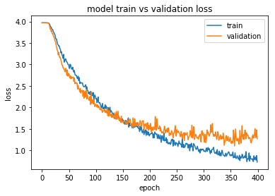

```python
# plot train and validation loss
pyplot.plot(history.history['loss'])
pyplot.plot(history.history['val_loss'])
pyplot.title('model train vs validation loss')
pyplot.ylabel('loss')
pyplot.xlabel('epoch')
pyplot.legend(['train', 'validation'], loc='upper right')
pyplot.show()
```

#### Verdict: Not good enough

This straightforward sequential model at the end gave me an accuracy of 71% on training set and 66% on test set. It gives overall 5% improvement over the baseline Naive Bayes model.  
There is some improvement but not enough. Also, the model seems to be getting very unstable at the end with high variations in the validation loss. I fiddled around with parameters, increased the epochs, etc but the best accuracy I got has been below 70% on the validation set. Lets try an alternative approach.

##### Attempt 2 with attention

I have been reading about attention for a while. But never really got a chance to implement it yet. I thought I will try implementing here.  
Recurrent networks with attention enables the model to focus more on certain aspects of the sequence.  
It was not straightforward implementing attention in Keras but I did find a good resource with the link posted below.

*REF: https://github.com/keras-team/keras/issues/4962*

```python
EMBEDDING_SIZE=len(feneme_dict)+1
EMBEDDING_DIM=25
```

```python
inputs=Input(shape=(None,))
embeddings=Embedding(
            input_dim=EMBEDDING_SIZE,
            output_dim=EMBEDDING_DIM,
            input_length=X.shape[1],
            trainable=True,
            mask_zero=True)(inputs)

lstm=LSTM(128, dropout=0.4, recurrent_dropout=0.4, return_sequences=True)(embeddings)

attention = TimeDistributed(Dense(1, activation='tanh'))(lstm)
attention = Flatten()(attention)
attention = Activation('softmax')(attention)
attention = RepeatVector(128)(attention)
attention = Permute([2, 1])(attention)

#sent_representation = merge([activations, attention], mode='mul')
sent_representation = Multiply()([lstm, attention])
sent_representation = Lambda(lambda xin: Ksum(xin, axis=1))(sent_representation)

outputs = Dense(NUM_LABELS, activation='softmax')(sent_representation)

model = Model(inputs=inputs, outputs=outputs)

model.compile(loss='categorical_crossentropy', optimizer='adam', metrics=['accuracy'])
```

```python
epochs=640
batch_size=96
```

```python
history = model.fit(X, y,
                    epochs=epochs,
                    batch_size=batch_size ,validation_split=0.2 #,
                   # callbacks=[EarlyStopping(monitor='val_loss', patience=3, min_delta=0.0001)]
                   )
```

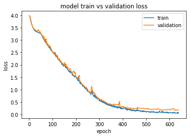

```python
# plot train and validation loss
pyplot.plot(history.history['loss'])
pyplot.plot(history.history['val_loss'])
pyplot.title('model train vs validation loss')
pyplot.ylabel('loss')
pyplot.xlabel('epoch')
pyplot.legend(['train', 'validation'], loc='upper right')
pyplot.show()
```

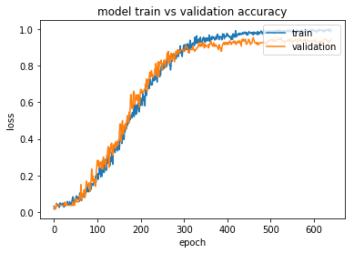

```python
# plot train and validation accuracies
pyplot.plot(history.history['accuracy'])
pyplot.plot(history.history['val_accuracy'])
pyplot.title('model train vs validation accuracy')
pyplot.ylabel('loss')
pyplot.xlabel('epoch')
pyplot.legend(['train', 'validation'], loc='upper right')
pyplot.show()
```

#### Verdict: Success!

##### Training Sub-Attempt 1

- Validation Accuracy: 83%
- Train Accuracy: 96%

To be honest it's my best time implementing attention. Hence, I may not be clear on some of the concepts.  
But it seems and model performance has improved considerably with more than 15% increase over non-attention based network.  
*(There is some overfitting though)*  
We can try increasing the epochs and see if the accuracy improves further but it seems around 300th epoch validation loss execeeded train loss and it looks like the accuracy might not improve by a good margin even after fiddling with some parameters. Instead lets try alternative approach!

##### Training Sub-Attempt 2

- Validation Accuracy: 94%
- Train Accuracy: 99%

Wow, I just made a small change (increased the embedding dimensions from 10 to 25) and reran the model. The accuracy shot up like crazy. I did this change after implementing the models below. So this is my latest model!

I am tempted to fiddle with embedding dimensions further but would like to keep that for another day :)

```python
##Oops, Before that, saving this model for future use
save_model(model,'lstm_attention')
```

```
Saved model to disk
```

```python
model_lstm_attn=reload_model('lstm_attention')
```

```
Loaded model from disk
```

##### Attempt 3 - Deeper model with attention

```python
inputs=Input(shape=X.shape[1])
embeddings=Embedding(
            input_dim=EMBEDDING_SIZE,
            output_dim=EMBEDDING_DIM,
            input_length=X.shape[1],
            trainable=True,
            mask_zero=True)(inputs)

spdrop=SpatialDropout1D(0.2)(embeddings)

conv1D=Conv1D(filters=16, kernel_size=(4), padding='same', activation='relu')(spdrop)

lstm=LSTM(128, dropout=0.4, recurrent_dropout=0.4, return_sequences=True)(conv1D)

attention = TimeDistributed(Dense(1, activation='tanh'))(lstm)
attention = Flatten()(attention)
attention = Activation('softmax')(attention)
attention = RepeatVector(128)(attention)
attention = Permute([2, 1])(attention)

sent_representation = Multiply()([lstm, attention])
sent_representation = Lambda(lambda xin: Ksum(xin, axis=1))(sent_representation)
dense=Dense(108,activation='relu')(sent_representation)
outputs = Dense(NUM_LABELS, activation='softmax')(dense)

model = Model(inputs=inputs, outputs=outputs)

model.compile(loss='categorical_crossentropy', optimizer='adam', metrics=['accuracy'])
```

```python
history = model.fit(X, y,
                    epochs=epochs,
                    batch_size=batch_size ,validation_split=0.2 #,
                   # callbacks=[EarlyStopping(monitor='val_loss', patience=3, min_delta=0.0001)]
                   )
```

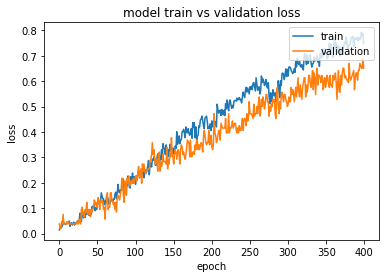

```python
# plot train and validation loss
pyplot.plot(history.history['accuracy'])
pyplot.plot(history.history['val_accuracy'])
pyplot.title('model train vs validation loss')
pyplot.ylabel('loss')
pyplot.xlabel('epoch')
pyplot.legend(['train', 'validation'], loc='upper right')
pyplot.show()
```

#### Verdict: Failure

- Validation Accuracy: 65%
- Training Accuracy: 74%  
  It seems to perform poorer as compared to the simple lstm model with attention

I also tried changing couple of parameters (dense layers, maxpooling, etc) yet the model failed to perform well. Model accuracy can improve further if we try increasing the epochs. But it looks like model is becoming exceedingly unstable at the end. (Increasing embedding dims might also work, but since I observed that later on, I would like to park any experimentation at this point in time)

##### Attempt 4 : Using Sequence to sequence model

*Ref:https://blog.keras.io/a-ten-minute-introduction-to-sequence-to-sequence-learning-in-keras.html*

train_transcripts can be considered as a sequence of characters and we try modelling with this approach

Since, I assumed earlier that fenemes relate to prouniciation of words, it might be a good idea to make our model learn these feneme variations and train it to recognize character pronounciations. Implementing this with attention might give good results.

Since all the previous models were based on sequence classifcation, I may have to do some feature engineering so as to make the data compliant with sequence to sequence model.

4.1 Utility functions to help me with encoding and decoding

```python
## Create feature dict
features='1234567890abcdefghijklmnopqrstuvwxyz <>'
feature_dict=defaultdict(int)
count=0
for f in features:
    count+=1
    feature_dict[f] += count # increment element's value by 1

inv_feature_dict = {v: k for k, v in feature_dict.items()}


def split(word):
    return [char for char in word]
## Encode and decode features
def encode_label_seq(text, feature_dict=feature_dict):
    code=[]
    text=text.lower()
    text='<'+text+'>'
    for charac in text:
        code.append(feature_dict[charac])
    return code

def decode_label_seq(seq, mapping=inv_feature_dict):
    seq_d=[]
    for num in seq:
        n=int(np.round(num[0]))
        seq_d.append(mapping[n])
    return ''.join(seq_d)
```

```python
train_transcripts_char=[encode_label_seq(seq) for seq in train_transcripts_r]
```

4.2 Padding

```python
MAX_LABEL_SEQ_LEN=0
for seq in train_transcripts_char:
    if len(seq) > MAX_LABEL_SEQ_LEN:
        MAX_LABEL_SEQ_LEN=len(seq)
print('Seq length considering endpoints and end tokens:',MAX_LABEL_SEQ_LEN)
```

```
Seq length considering endpoints and end tokens: 19
```

```python
train_transcripts_char=pad_sequences(train_transcripts_char,MAX_LABEL_SEQ_LEN)
```

4.3 Architecture:  
The architecture I am intend to use here is an LSTM based encoder - decoder one.  
The encoder with learn the context of the input sequences and pass those hidden states to the decoder.  
The decoder is set to predict the next character of the target sequence.

```python
decoder_inp=pad_sequences([s[:-1] for s in train_transcripts_char])
decoder_op=pad_sequences([s[1:] for s in train_transcripts_char])
```

```python
def onehot_encode_array(np_arr):
    flat_arr=[item for seq in np_arr for item in seq]
    len_enc=max(flat_arr)+1
    encoded_matrix=np.zeros((np_arr.shape[0],np_arr.shape[1],len_enc))
    for i in range(np_arr.shape[0]):
        for j in range(np_arr.shape[1]):
            encoded_matrix[i,j,np_arr[i,j]]=1
    return encoded_matrix
```

```python
decoder_op=onehot_encode_array(decoder_op)
```

```python
num_encoder_tokens=len(set(feneme_set))+3 # +3 to consider start and end tokens and default character
num_decoder_tokens=len(feature_dict)+1
latent_dim=12
encoder_input_data=X
```

```python
print('# Encoder tokens',num_encoder_tokens)
print('# Decoder tokens',num_decoder_tokens)
print('# embdedding dims',latent_dim)
print('# Encoder Input',X.shape)
print('# Decoder Input',decoder_op.shape)
```

```
# Encoder tokens 309
# Decoder tokens 40
# embdedding dims 12
# Encoder Input (530, 191)
# Decoder Input (530, 18, 40)
```

```python
encoder_inputs = Input(shape=(None,))
x = Embedding(num_encoder_tokens, latent_dim)(encoder_inputs)
x, state_h, state_c = LSTM(latent_dim,
                           return_state=True)(x)
encoder_states = [state_h, state_c]

# Set up the decoder, using `encoder_states` as initial state.
decoder_inputs = Input(shape=(None,))
x = Embedding(num_decoder_tokens, latent_dim)(decoder_inputs)
x, _,_ = LSTM(latent_dim, return_sequences=True, return_state=True)(x, initial_state=encoder_states)
#x = Lambda(lambda xin: Ksum(xin, axis=1))(x)
decoder_outputs = Dense(num_decoder_tokens, activation='softmax')(x)

# Define the model that will turn
# `encoder_input_data` & `decoder_input_data` into `decoder_target_data`
model = Model([encoder_inputs, decoder_inputs], decoder_outputs)

# Compile & run training
model.compile(loss='categorical_crossentropy', optimizer='adam', metrics=['accuracy'])
# Note that `decoder_target_data` needs to be one-hot encoded,
# rather than sequences of integers like `decoder_input_data`!
```

```python
model.summary()
```

```
Model: "model_27"
__________________________________________________________________________________________________
Layer (type)                    Output Shape         Param #     Connected to
==================================================================================================
input_77 (InputLayer)           [(None, None)]       0
__________________________________________________________________________________________________
input_78 (InputLayer)           [(None, None)]       0
__________________________________________________________________________________________________
embedding_66 (Embedding)        (None, None, 12)     3708        input_77[0][0]
__________________________________________________________________________________________________
embedding_67 (Embedding)        (None, None, 12)     480         input_78[0][0]
__________________________________________________________________________________________________
lstm_82 (LSTM)                  [(None, 12), (None,  1200        embedding_66[0][0]
__________________________________________________________________________________________________
lstm_83 (LSTM)                  [(None, None, 12), ( 1200        embedding_67[0][0]
                                                                 lstm_82[0][1]
                                                                 lstm_82[0][2]
__________________________________________________________________________________________________
dense_39 (Dense)                (None, None, 40)     520         lstm_83[0][0]
==================================================================================================
Total params: 7,108
Trainable params: 7,108
Non-trainable params: 0
__________________________________________________________________________________________________
```

```python
model.fit([encoder_input_data, decoder_inp], decoder_op,
          batch_size=batch_size,
          epochs=epochs,
          validation_split=0.2)
```

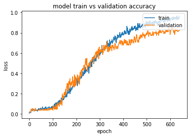

```python
# plot train and validation loss
pyplot.plot(history.history['accuracy'])
pyplot.plot(history.history['val_accuracy'])
pyplot.title('model train vs validation accuracy')
pyplot.ylabel('loss')
pyplot.xlabel('epoch')
pyplot.legend(['train', 'validation'], loc='upper right')
pyplot.show()
```

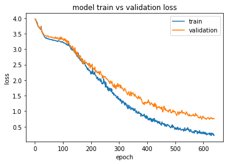

```python
# plot train and validation loss
pyplot.plot(history.history['loss'])
pyplot.plot(history.history['val_loss'])
pyplot.title('model train vs validation loss')
pyplot.ylabel('loss')
pyplot.xlabel('epoch')
pyplot.legend(['train', 'validation'], loc='upper right')
pyplot.show()
```

#### Verdict: Not bad

Seems to work well. There is slight overfitting. But overall this model may hold greater potential. I also believe using attention with this approach would yield pretty good results. However, in interest of time I think I would stop fiddling around and use the model from attempt 2 for predictions.

```python
save_model(model,'_seq2seq')
```

```
Saved model to disk
```

```python
loaded_seq2seq_model=reload_model('_seq2seq')
```

```
Loaded model from disk
```

Hence for now, I would like to submit my model from attempt two. Attaching the json and h5 file to my submission.

### 5 Predictions

```python
model_lstm_attn=reload_model('lstm_attention')
```

```
Loaded model from disk
```

I just noticed: there are no testing endpoints. It seems I would have to develop a model to recognize endpoints first as this model didn't work on training data without endpoints fitler. It does work on some but not all.

```python
encoded_train_r=[encode_seq(seq) for seq in train_features_r]
XX=pad_sequences(encoded_train_r,800,padding='post')
XX=XX[0:-1]
```

```python
start_endpoints=[endpoints[0]+1 for endpoints in train_endpoints]
end_endpoints=[endpoints[1]+1 for endpoints in train_endpoints]
## Adding 1 to consider the START token of sequences
```

```python
MAX_LENGTH_r=0
for seq in encoded_train_r:
    if len(seq) > MAX_LENGTH_r:
        MAX_LENGTH_r=len(seq)
print('Seq length considering endpoints and end tokens:',MAX_LENGTH_r)
```

```
Seq length considering endpoints and end tokens: 402
```

```python
def onehot_encode_vector(np_arr, onehot_length=800):
    np_arr=np.array(np_arr)
    #flat_arr=[item for seq in np_arr for item in seq]
    if onehot_length < max(np_arr)+1:
        onehot_length=max(np_arr)+1
    encoded_matrix=np.zeros((np_arr.shape[0],onehot_length))
    for i in range(np_arr.shape[0]):
            encoded_matrix[i,np_arr[i]]
    return encoded_matrix
```

```python
start_endpoints_onehot=onehot_encode_vector(start_endpoints)
```

```python
embedding_size=len(feneme_dict)
embedding_dim=24
num_classes=len(start_endpoints_onehot[0])
```

#### 5.1 Featurize test data

```python
test_features_r=[feneme.split(' ') for feneme in read_text(r'test_features.txt').split('\n')]
```

```python
encoded_test_features=[encode_seq(seq) for seq in test_features_r]
```

I tried couple of ideas but I couldnt find a way to train a model so as to extract endpoints. I think I am going to submit this as it is. May be there is a better way to design a model which trains on endpoints as well.

#### 5.2 Try with train data

```python
def compare_output(seq_num, model=model_lstm_attn):
    tr0=train_features[seq_num]
    tl0=train_transcripts_r[seq_num]
    print('Train Label:',tl0)
    tr0_m=encode_seq(np.array(tr0))
    tp0=argmax(model.predict(np.array([tr0_m])))
    print('Predicted Label (with endpoints filter)',label_encoder.inverse_transform([tp0]))
    tre=train_features_r[seq_num]
    tre_m=encode_seq(np.array(tre))
    tp0e=argmax(model.predict(np.array([tre_m])))
    print('Predicted Label (w/0 endpoints filter)',label_encoder.inverse_transform([tp0e]))
```

```python
compare_output(181)
```

```
Train Label: shuffledown
Predicted Label (with endpoints filter) ['shuffledown']
Predicted Label (w/0 endpoints filter) ['h3']
```

```python
compare_output(21)
```

```
Train Label: lowertopwindow
Predicted Label (with endpoints filter) ['lowertopwindow']
Predicted Label (w/0 endpoints filter) ['lowertopwindow']
```

```python
compare_output(501)
```

```
Train Label: raise
Predicted Label (with endpoints filter) ['raise']
Predicted Label (w/0 endpoints filter) ['h3']
```

To Seasalt.ai team,  
Thank you very much for inviting me to this challenge.  
It was not only fun in trying to come up with ways to solving but it was an excellent learning experience for me. Regardless whether I get selected or not. I'll be truly grateful for this assignment.

Also, I had a really rough two weeks, due to finals, roommates getting sick with COVID-19 and me having to move out to a different location. Thanks for giving me more time for this submission and apologies for not being able to figure out the last part. I greatly appreciate your support.

Warm Regards,  
Ajinkya